# Research Design

SKOC62: Research Methods  
in Strategic Communication 2026

nils.holmberg@iko.lu.se

## Course literature

[figure not shown]

6 and Bellamy (2011)

[figure not shown]

Trost and Hultåker (2016)

[figure not shown]

Djurfeldt, Larsson, and Stjärnhagen (2003)

## Lecture overview

- `Research Design`
- Epistemology
- Reasoning logic
- `Qualitative research`
- Phenomenology
- Case study
- Content analysis
- `Quantitative research`
- Descriptive
- Correlational
- Experiments
- `Mixed methods`
- Convergent parallel
- Explanatory sequential

Research Design Concepts

## Positivism

#### Research design

- Positivism studies social life with measurable indicators and testable claims.
- Perspective: AI use and grade patterns across schools.
- Example: survey student AI frequency and assignment scores.
- Focus: standardized measures, comparability, and replicable procedures.
- Output: associations, predictions, and causal hypotheses.

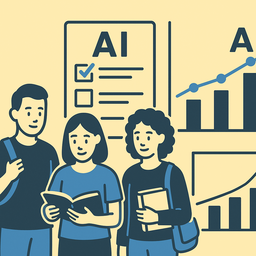

## Positivism

#### Research design

- Key inference: statistical explanation from sample patterns.
- Typical analyses: descriptives, correlation, and regression.
- Deductive flow: hypothesis -> measurement -> test.
- Claims: frequency, association, and prediction.
- Causality needs stronger design support than correlation alone.

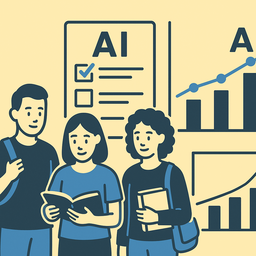

## Interpretivism

#### Research design

- Interpretivism centers meanings people attach to actions.
- Perspective: how students describe AI in everyday study work.
- Example: interviews on trust, pressure, and fairness.
- Focus: context, depth, and reflexive interpretation.
- Output: rich sense-making accounts, not universal laws.

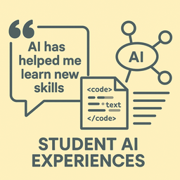

## Interpretivism

#### Research design

- Key inference: interpretive understanding of motives and meanings.
- Typical analyses: coding and thematic analysis of interviews.
- Inductive flow: narratives ->  
  themes -> concepts.
- Claims stay contextual and avoid over-generalization.
- Use case: explain how students frame AI as help or risk.

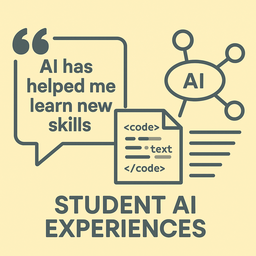

## Critical realism

#### Research design

- Critical realism asks which hidden structures produce visible outcomes.
- Perspective: AI behavior shaped by policy, inequality, and norms.
- Example: compare schools with different rules and resources.
- Focus: connect lived experience to institutional context.
- Output: mechanism-based explanations of patterned differences.

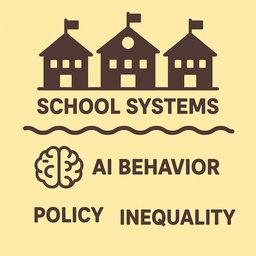

## Critical realism

#### Research design

- Key inference: mechanisms and conditions behind patterns.
- Data strategy: combine interviews, observation, and surveys.
- Analysis: triangulate evidence to test rival mechanisms.
- Claims explain why outcomes differ across contexts.
- Use case: identify barriers to equitable AI access.

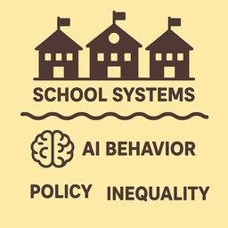

## Reasoning logics

#### Research design

- Deduction, induction, and abduction are core reasoning routes.
- Deduction tests theory-driven expectations.
- Induction builds concepts from repeated observations.
- Abduction proposes best explanations for anomalies.
- Design task: align question, evidence, and logic.

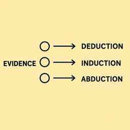

## Reasoning logics

#### Research design

- Deductive inference: general rule -> specific expectation.
- Inductive inference: cases -> broader pattern.
- Abductive inference: surprising  
  case -> plausible mechanism.
- Projects often cycle across all three logics.
- Use case: induce pattern, deduce test, abduct anomalies.

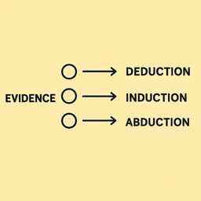

## Research proposal

#### Research design

- Early proposal work defines the problem, gap, and study purpose.
- Core step: convert the problem into a focused research question.
- Quantitative framing asks about variables, relationships, or effects.
- Qualitative framing asks about meanings, experiences, or processes.
- This choice sets scope, logic, and expected contribution.

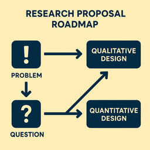

## Research proposal

#### Research design

- Late proposal stages specify data collection and analysis plans.
- Quantitative path: structured instruments, sampling, and measurement.
- Quantitative analysis tests hypotheses with statistics and models.
- Qualitative path: interviews or observation with coding and themes.
- Strong proposals align method, evidence, ethics, and claims.

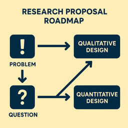

Qualitative Research Designs

## Phenomenological research design

#### Qualitative designs

- Studies lived meaning in a shared experience.
- Video example: cancer survivors describe life after treatment.
- Research question: How do survivors make sense of recovery?
- Research proposal: Interview 15 survivors across age groups.
- Perspective: interpretive and meaning-focused.

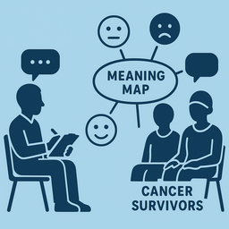

## Phenomenological research design

#### Qualitative designs

- Collect in-depth interviews and short reflective diaries.
- Use purposive sampling of participants with the same event.
- Transcribe recordings and code key meaning statements.
- Group codes into common themes and sharp contrasts.
- Example output: identity, fear, hope, and purpose themes.

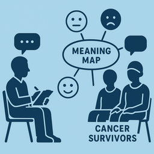

## Grounded theory research design

#### Qualitative designs

- Builds theory directly from field data.
- Video example: chronic-pain coping choices differ by person.
- Research question: What process drives coping choice over time?
- Research proposal: Follow 20 patients through three rounds.
- Perspective: strongly inductive and process-oriented.

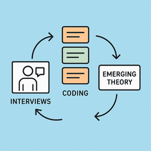

## Grounded theory research design

#### Qualitative designs

- Combine interviews with focused observations.
- Use theoretical sampling to test emerging categories.
- Apply open, focused, and axial coding in cycles.
- Compare new cases until saturation appears.
- Example model: support, cost, beliefs, and symptoms.

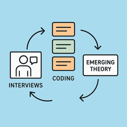

## Ethnographic research design

#### Qualitative designs

- Examines culture through long natural-setting immersion.
- Video example: school-bus bullying culture observation.
- Research question: How do rituals sustain group hierarchy?
- Research proposal: Observe one bus route for 8 weeks.
- Perspective: naturalistic, contextual, and insider-focused.

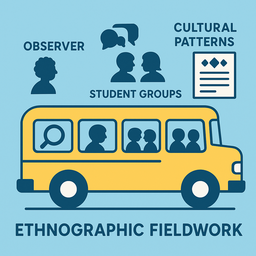

## Ethnographic research design

#### Qualitative designs

- Collect fieldnotes, informal interviews, and artifact photos.
- Use key informants to decode local norms.
- Code interactions, language, and recurring rituals.
- Build thick description across time and setting.
- Example output: rules, roles, sanctions, and resistance.

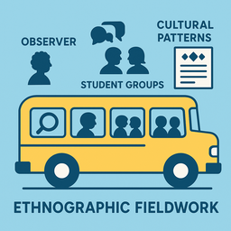

## Case study research design

#### Qualitative designs

- Investigates one bounded case in depth.
- Video example: one firm’s success across departments.
- Research question: Which factors explain this case outcome?
- Research proposal: Study one school innovation program.
- Perspective: contextual explanation over broad generalization.

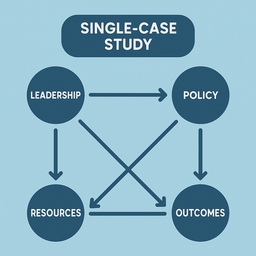

## Case study research design

#### Qualitative designs

- Gather interviews, documents, and focus-group feedback.
- Use purposive sampling across stakeholder roles.
- Triangulate sources to check or challenge claims.
- Code themes, then map links within the case.
- Example output: policy, leadership, resources, culture.

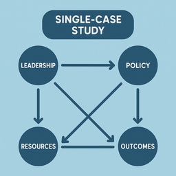

## Qualitative content analysis

#### Qualitative designs

- Identifies recurring themes in documents and text.
- Video example: school forum posts on citizenship behavior.
- Research question: How is responsible citizenship framed online?
- Research proposal: Analyze 300 posts from three schools.
- Perspective: interpretive with clear coding rules.

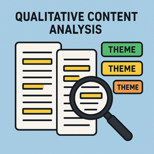

## Qualitative content analysis

#### Qualitative designs

- Collect documents, posts, newsletters, and comment threads.
- Build a coding frame with themes and subthemes.
- Code segments, then refine categories iteratively.
- Compare theme frequencies and key quotations.
- Example output: duty, rights, discipline, participation narratives.

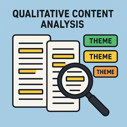

Quantitative Research Designs

## Descriptive research design

#### Quantitative designs

- Describes current patterns without manipulating variables.
- Video example: smartphone-addiction prevalence among teens.
- Research question: How common is smartphone addiction in this sample?
- Research proposal: Survey 400 students across 4 schools.
- Perspective: measurement-first and objective reporting.

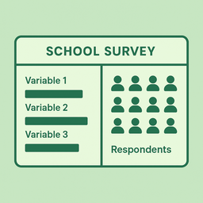

## Descriptive research design

#### Quantitative designs

- Collect structured survey responses at one time point.
- Use probability-style sampling where feasible.
- Clean and code responses into numeric fields.
- Analyze frequencies, means, and subgroup differences.
- Output: prevalence table by grade, gender, and school.

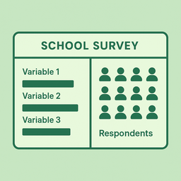

## Correlational research design

#### Quantitative designs

- Tests associations between variables without intervention.
- Video example: exercise frequency with blood pressure and BMI.
- Research question: How strongly does exercise relate to health indicators?
- Research proposal: Gather health and behavior data from 600 adults.
- Perspective: pattern detection and cautious prediction.

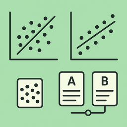

## Correlational research design

#### Quantitative designs

- Collect paired predictor and outcome measures.
- Add demographics and covariates for control.
- Check missingness and distribution quality.
- Run correlation and regression models.
- Output: effect size, confidence interval, and limits.

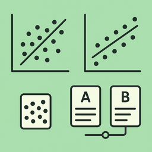

## Quasi-experimental research design

#### Quantitative designs

- Estimates likely effects without random assignment.
- Video example: new teaching method across existing classes.
- Research question: Does the method improve scores versus usual teaching?
- Research proposal: Compare 8 existing classes across two schools.
- Perspective: practical causality with real-world constraints.

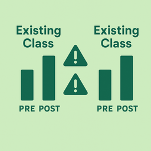

## Quasi-experimental research design

#### Quantitative designs

- Collect baseline and follow-up scores for intact groups.
- Track context factors like teacher and timetable.
- Use group comparisons with covariate adjustment.
- Test robustness with sensitivity checks.
- Output: estimated effect with clear validity caveats.

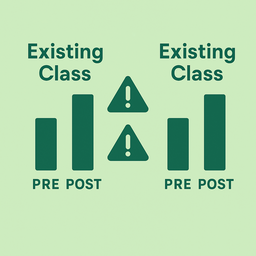